# R Notebook sandbox: Playing with Wikipedia

# 1 Top of the world

A comment about this notebook: trying to Knit does not make much sense, run one chunck at a time, and observe.

# 2 Parsing Content From Wikipedia

In this notebook, we are going to parse some data from wikipedia. Some of it was simple, and other elements were tricky. For simple, I used `rvest`. For not-so-simple, I used `xml2` which `rvest` is built upon. And for the really tricky ones, I used my past experience. For small datasets, these `R` approaches are fine, but if you want to do some serious data harvesting and parsing, you should use the C-based language that is the fastest in the world at parsing. That would not be `R`.

**War story rant** … I have probably downloaded over 15 million pages over the last 10 years or so. That is direct downloads, you parallel-process and you don’t over-slurp, you do not want to be a DDOS attack. I also have downloaded large tar.gz time files and processed them. Of interest to some of you may be the OCR project we did with older patents, such as Abraham Lincoln’s 6469 patent. We used `tesseract` to OCR over 100 million patent pages and do cleanup procedures on old ones. At the time, our quality was better than Google patents (e.g., 2014-ish). Likely, it still may be today. If you care about clean data, then you make efforts to clean the data. You can see a few YouTube videos on how to train `tesseract` to be smarter. It doesn’t work. We need a new engine. A better engine. A grid-approach engine that could use modern-GPUs. Our Phase I proposal was a bit of money, but we did not receive funding in Phase II to make that new grid-approach engine a reality. Not the end of the world, but I will stop with my sidebar…

From Wikipedia, we are going to grab some basic data from a page, if it exists; otherwise, we will return (NA). Good data provenance is about keeping a “chain of custody” with your process. So at times, I could go back and change a previous `for-loop` but it makes it more difficult to review later. I call this the “sweeping” approach. Do one sweep at a time, keep them independent. You may have to rewind to a certain “sweep” stage, but that is fine. Each stage should have an objective.

- Download and Cache the webpage. Simple enough objective and essential for good data provenance. I can still use `rvest` but I will develop my own caching mechanisms.
- Parsing strategies. Again, cache anything that has already been parsed. The next time, it just grabs the result and moves own. If you code in a “parallel” form, you are copying/pasting code blocks and making minimal changes. Some believe there is a “perfect abstract” solution. Maybe there is, but I can get to work and use “git r done” and have millions of pages downloaded and parsed before you finish your perfect “abstraction” solution.
- `Latitude/Longitude`: If the webpage has this, it will grab the first instance. On most city/state pages, that is the correct form. Some UTF-8 issues will arise, I tried to pass `https://en.wikipedia.org/wiki/Ober%C3%A1` into the system, and it failed miserably, as in crashing both RGui and RStudio a few days ago. Tools->Global Options->Code->Saving … select UTF-8 … I had written a function to deal with the latitude/longitude degree symbols an it created havoc. Even on github. The `a grave` in `Ober%C3%A1` was not friendly. I have also noticed that if I choose UTF-8 to save data files in “.rds” format, the file compression gain is now a loss. So it is something to be aware of, and I will probably ignore encoding=“UTF-8” unless it really mattes.
- `Tables` in general: I look for all tables, then do a wildcard search on the content looking for a known unique data element (e.g., “`*Climate Data`”).
- `Climate Data`: This is a common table that has temperature, precipitation, and for some locations, so much more (e.g., compare `Whitefish, Montana` to `Manhattan` [New York]). I could have grabbed just the top-half of each row, but in this “sweep” I am already coding, so I have this inclination to get all the relevant data. `units=1` is the top value and `units=2` is the bottom value, if it exists.
- `Historic Population`: This is decade-level census data (every 10 years) with some surprise bonus data. This is a vertically-formatted table and the basic `rvest::html_tabl` fails spectacularly. After trying to use their tools, I just did the “hold my rootbeer” thing and did it my own way.
- `State Capitals`: I will demonstrate a few pages, one-offs, where you have to know the URL of Wikipedia to make it happen. Then I parse https://en.wikipedia.org/wiki/List_of_capitals_in_the_United_States#State_capitals which `rvest` handles nicely, so there is little for me to do. Since each state capital probably has a history elsewhere on the page, I had to use a unique wildcard search to guarantee the result …

`my.table = wiki.findMyTable(tables,"*2716.7*"); # Alaska area should be unique`

```r
library(devtools);
library(humanVerseWSU);
packageVersion("humanVerseWSU");  # should be ‘0.1.4’+
```

```
## [1] '0.1.4.2'
```

```r
# how long after commit/push before "raw" becomes live?
# unraw was immediate ...  3:50 AM ... about 7 minutes https://github.com/MonteShaffer/humanVerseWSU/blob/master/humanVerseWSU/R/functions-cleanup.R
# sometimes it is immediate ...

path.github = "https://raw.githubusercontent.com/MonteShaffer/humanVerseWSU/master/";

# a few DMS <--> DEC conversion tools for lat/long ... in the end, I didn't need them ...
# source("C:/_git_/MonteShaffer/humanVerseWSU/humanVerseWSU/R/functions-maths.R");
## I reorganized the `grabHTML` function that is the key driver of the caching system ... It is not compiled yet, so grab it from its source_url
source_url( paste0(path.github, "humanVerseWSU/R/functions-file.R") );

## I may never directly wrap them into the library ... harvesting/parsing are tasks/processes that need to be performed and documented, that does not mean they belong as "public functions" in the library
source_url( paste0(path.github, "humanVerseWSU/R/functions-wikipedia.R") );

# UTF encoding issues ... notice the degree symbol, the single quote that is not really, and the double-quote that is not really...
# wiki.cleanupDMStoDecLatitudeLongitude("48°22′13″N 114°11′20″W");
# the above function can be found in humanVerseWSU/compiling/_stuff_/ just as an archive ...
```

# 3 Local Data Storage

We need a location to store our data (page.html). I will create folder name, based on the wiki-page name. I have a way to convert `back-and-forth` if necessary, see: `wiki.parseWikiPageToString` and `wiki.parseWikiStringBackToPage`. Files that will currently be stored in the folder, see your version of `R:\Wikipedia\en^wikipedia^org-wiki-Atlanta\`

- `page.html` is the raw.html file
- `coordinates.txt` contains latitude/longitude
- `climate.html` and `climate.rds` and temporary in-between file to allow `xml2::` to play nice with my custom code
- `population.txt` contains the historical population data

```r
local.data.path = "R:/";  # to store HTML files, cached data-objects
      # I generally use large drives because they fill up
      # Having the C:/ run out can be bad
      # Today's project [~6MB zipped]
path.wiki = paste0(local.data.path,"Wikipedia/");
createDirRecursive(path.wiki);
```

You can read the functions if you would like, but let’s try out my hometown `Columbia Falls, Montana` …

## 3.1 Download the file

```r
wiki.url = "https://en.wikipedia.org/wiki/Columbia_Falls,_Montana";

wiki.info = wiki.downloadWikiPage(wiki.url, path.wiki);
```

```
## [1] "grabHTML() ... from cache ... R:/Wikipedia/en^wikipedia^org-wiki-Columbia_Falls+_Montana/page.html"
```

```r
    str(wiki.info);
```

```
## List of 2
##  $ path.wiki.page: chr "R:/Wikipedia/en^wikipedia^org-wiki-Columbia_Falls+_Montana/"
##  $ wiki.html     : chr "R:/Wikipedia/en^wikipedia^org-wiki-Columbia_Falls+_Montana/page.html"
```

```r
# check your folder and make certain 'page.html' lives in the expected folder
```

## 3.2 Let’s do some parsing

```r
latlong = wiki.findCoordinates(wiki.info$path.wiki.page, wiki.info$wiki.html);
    latlong;
```

```
## [1]   48.37028 -114.18889
```

```r
population = wiki.historicalPopulation(wiki.info$path.wiki.page, wiki.info$wiki.html);
    population;
```

| year | population |
| --- | --- |
| 1910 | 601 |
| 1920 | 611 |
| 1930 | 637 |
| 1940 | 637 |
| 1950 | 1232 |
| 1960 | 2132 |
| 1970 | 2652 |
| 1980 | 3112 |
| 1990 | 2942 |
| 2000 | 3645 |

[output cut: 1 more lines]

```r
climate = wiki.parseAverageClimate(wiki.info$path.wiki.page, wiki.info$wiki.html);
  str(climate);  # doesn't exist ...
```

```
##  logi NA
```

Check out `coordinates.txt` and `population.txt` … there is not any `climate-data` because the page doesn’t have it.

## 3.3 Another place nearby Whitefish, Montana

I was technically born in the `Whitefish hospital`, so let’s do that one next. It has climate data.

```r
wiki.url = "https://en.wikipedia.org/wiki/Whitefish,_Montana";

wiki.info = wiki.downloadWikiPage(wiki.url, path.wiki);
```

```
## [1] "grabHTML() ... from cache ... R:/Wikipedia/en^wikipedia^org-wiki-Whitefish+_Montana/page.html"
```

```r
    str(wiki.info);
```

```
## List of 2
##  $ path.wiki.page: chr "R:/Wikipedia/en^wikipedia^org-wiki-Whitefish+_Montana/"
##  $ wiki.html     : chr "R:/Wikipedia/en^wikipedia^org-wiki-Whitefish+_Montana/page.html"
```

```r
latlong = wiki.findCoordinates(wiki.info$path.wiki.page, wiki.info$wiki.html);
    latlong;
```

```
## [1]   48.41167 -114.34000
```

```r
population = wiki.historicalPopulation(wiki.info$path.wiki.page, wiki.info$wiki.html);
    population;
```

| year | population |
| --- | --- |
| 1890 | 640 |
| 1900 | 446 |
| 1910 | 417 |
| 1920 | 574 |
| 1930 | 575 |
| 1940 | 858 |
| 1950 | 1025 |
| 1960 | 1519 |
| 1970 | 3349 |
| 1980 | 3703 |

[output cut: 3 more lines]

```r
climate = wiki.parseAverageClimate(wiki.info$path.wiki.page, wiki.info$wiki.html);
  str(climate);
```

```
## List of 2
##  $ title: chr "Climate data for Whitefish, Montana (1981Â–2010 normals)"
##  $ df   :'data.frame':   14 obs. of  14 variables:
##   ..$ units: num [1:14] 1 2 1 2 1 2 1 2 1 2 ...
##   ..$ key  : chr [1:14] "Record high F (C)" "Record high F (C)" "Average high F (C)" "Average high F (C)" ...
##   ..$ Jan  : num [1:14] 50 10 29.3 -1.5 22.5 -5.3 15.6 -9.1 -26 -32 ...
##   ..$ Feb  : num [1:14] 63 17 34.5 1.4 25.2 -3.8 15.8 -9 -27 -33 ...
##   ..$ Mar  : num [1:14] 74 23 43.5 6.4 33.1 0.6 22.7 -5.2 -15 -26 ...
##   ..$ Apr  : num [1:14] 79 26 54.3 12.4 42.1 5.6 29.9 -1.2 11 -12 ...
##   ..$ May  : num [1:14] 89 32 63.4 17.4 50.8 10.4 38.2 3.4 19 -7 ...
##   ..$ Jun  : num [1:14] 95 35 70.4 21.3 57.7 14.3 44.9 7.2 28 -2 ...
##   ..$ Jul  : num [1:14] 103 39 80.3 26.8 64.9 18.3 49.5 9.7 32 0 ...
##   ..$ Aug  : num [1:14] 100 38 79.9 26.6 64 18 48.1 8.9 30 -1 ...
##   ..$ Sep  : num [1:14] 94 34 68 20 53.6 12 39.2 4 19 -7 ...
##   ..$ Oct  : num [1:14] 80 27 53.2 11.8 41.8 5.4 30.4 -0.9 0 -18 ...
##   ..$ Nov  : num [1:14] 69 21 37.4 3 30.6 -0.8 23.9 -4.5 -13 -25 ...
##   ..$ Dec  : num [1:14] 48 9 28.2 -2.1 21.9 -5.6 15.6 -9.1 -33 -36 ...
```

```r
climate$df;
```

| units | key | Jan | Feb | Mar | Apr | May | Jun | Jul | Aug | Sep | Oct | Nov | Dec |
| --- | --- | --- | --- | --- | --- | --- | --- | --- | --- | --- | --- | --- | --- |
| 1 | Record high F (C) | 50.00 | 63.00 | 74.00 | 79.00 | 89.00 | 95.00 | 103.00 | 100.00 | 94.00 | 80.00 | 69.00 | 48.00 |
| 2 | Record high F (C) | 10.00 | 17.00 | 23.00 | 26.00 | 32.00 | 35.00 | 39.00 | 38.00 | 34.00 | 27.00 | 21.00 | 9.00 |
| 1 | Average high F (C) | 29.30 | 34.50 | 43.50 | 54.30 | 63.40 | 70.40 | 80.30 | 79.90 | 68.00 | 53.20 | 37.40 | 28.20 |
| 2 | Average high F (C) | -1.50 | 1.40 | 6.40 | 12.40 | 17.40 | 21.30 | 26.80 | 26.60 | 20.00 | 11.80 | 3.00 | -2.10 |
| 1 | Daily mean F (C) | 22.50 | 25.20 | 33.10 | 42.10 | 50.80 | 57.70 | 64.90 | 64.00 | 53.60 | 41.80 | 30.60 | 21.90 |
| 2 | Daily mean F (C) | -5.30 | -3.80 | 0.60 | 5.60 | 10.40 | 14.30 | 18.30 | 18.00 | 12.00 | 5.40 | -0.80 | -5.60 |
| 1 | Average low F (C) | 15.60 | 15.80 | 22.70 | 29.90 | 38.20 | 44.90 | 49.50 | 48.10 | 39.20 | 30.40 | 23.90 | 15.60 |
| 2 | Average low F (C) | -9.10 | -9.00 | -5.20 | -1.20 | 3.40 | 7.20 | 9.70 | 8.90 | 4.00 | -0.90 | -4.50 | -9.10 |
| 1 | Record low F (C) | -26.00 | -27.00 | -15.00 | 11.00 | 19.00 | 28.00 | 32.00 | 30.00 | 19.00 | 0.00 | -13.00 | -33.00 |
| 2 | Record low F (C) | -32.00 | -33.00 | -26.00 | -12.00 | -7.00 | -2.00 | 0.00 | -1.00 | -7.00 | -18.00 | -25.00 | -36.00 |

[output cut: 4 more lines]

## 3.4 Wenatchee, Washington

The climate data is similar, but the data frame is not exactly the same size.

```r
wiki.url = "https://en.wikipedia.org/wiki/Wenatchee,_Washington";

wiki.info = wiki.downloadWikiPage(wiki.url, path.wiki);
```

```
## [1] "grabHTML() ... from cache ... R:/Wikipedia/en^wikipedia^org-wiki-Wenatchee+_Washington/page.html"
```

```r
    str(wiki.info);
```

```
## List of 2
##  $ path.wiki.page: chr "R:/Wikipedia/en^wikipedia^org-wiki-Wenatchee+_Washington/"
##  $ wiki.html     : chr "R:/Wikipedia/en^wikipedia^org-wiki-Wenatchee+_Washington/page.html"
```

```r
latlong = wiki.findCoordinates(wiki.info$path.wiki.page, wiki.info$wiki.html);
    latlong;
```

```
## [1]   47.42333 -120.32528
```

```r
population = wiki.historicalPopulation(wiki.info$path.wiki.page, wiki.info$wiki.html);
    population;
```

| year | population |
| --- | --- |
| 1900 | 451 |
| 1910 | 4050 |
| 1920 | 6324 |
| 1930 | 11627 |
| 1940 | 11620 |
| 1950 | 13072 |
| 1960 | 16726 |
| 1970 | 16912 |
| 1980 | 17257 |
| 1990 | 21756 |

[output cut: 2 more lines]

```r
climate = wiki.parseAverageClimate(wiki.info$path.wiki.page, wiki.info$wiki.html);
  str(climate);
```

```
## List of 2
##  $ title: chr "Climate data for Wenatchee (1971-2000)"
##  $ df   :'data.frame':   12 obs. of  14 variables:
##   ..$ units: num [1:12] 1 2 1 2 1 2 1 2 1 2 ...
##   ..$ key  : chr [1:12] "Record high F (C)" "Record high F (C)" "Average high F (C)" "Average high F (C)" ...
##   ..$ Jan  : num [1:12] 65 18 35.1 1.7 29.2 -1.6 23.2 -4.9 -17 -27 ...
##   ..$ Feb  : num [1:12] 66 19 42.8 6 35.1 1.7 27.4 -2.6 -18 -28 ...
##   ..$ Mar  : num [1:12] 78 26 54.9 12.7 44.4 6.9 33.9 1.1 5 -15 ...
##   ..$ Apr  : num [1:12] 93 34 64.6 18.1 52.7 11.5 40.8 4.9 20 -7 ...
##   ..$ May  : num [1:12] 104 40 73.1 22.8 60.9 16.1 48.6 9.2 27 -3 ...
##   ..$ Jun  : num [1:12] 107 42 80.1 26.7 67.8 19.9 55.5 13.1 39 4 ...
##   ..$ Jul  : num [1:12] 110 43 88 31.1 74.4 23.6 61 16.1 40 4 ...
##   ..$ Aug  : num [1:12] 106 41 88 31.1 73.7 23.2 60.2 15.7 41 5 ...
##   ..$ Sep  : num [1:12] 101 38 77.7 25.4 64.5 18.1 51.2 10.7 21 -6 ...
##   ..$ Oct  : num [1:12] 90 32 63.7 17.6 52.3 11.3 40.8 4.9 19 -7 ...
##   ..$ Nov  : num [1:12] 76 24 46 7.8 39.1 3.9 32.2 0.1 0 -18 ...
##   ..$ Dec  : num [1:12] 67 19 35.7 2.1 30.5 -0.8 25.2 -3.8 -19 -28 ...
```

```r
climate$df;
```

| units | key | Jan | Feb | Mar | Apr | May | Jun | Jul | Aug | Sep | Oct | Nov | Dec |
| --- | --- | --- | --- | --- | --- | --- | --- | --- | --- | --- | --- | --- | --- |
| 1 | Record high F (C) | 65.00 | 66.00 | 78.00 | 93.00 | 104.00 | 107.00 | 110.0 | 106.00 | 101.0 | 90.00 | 76.00 | 67.00 |
| 2 | Record high F (C) | 18.00 | 19.00 | 26.00 | 34.00 | 40.00 | 42.00 | 43.0 | 41.00 | 38.0 | 32.00 | 24.00 | 19.00 |
| 1 | Average high F (C) | 35.10 | 42.80 | 54.90 | 64.60 | 73.10 | 80.10 | 88.0 | 88.00 | 77.7 | 63.70 | 46.00 | 35.70 |
| 2 | Average high F (C) | 1.70 | 6.00 | 12.70 | 18.10 | 22.80 | 26.70 | 31.1 | 31.10 | 25.4 | 17.60 | 7.80 | 2.10 |
| 1 | Daily mean F (C) | 29.20 | 35.10 | 44.40 | 52.70 | 60.90 | 67.80 | 74.4 | 73.70 | 64.5 | 52.30 | 39.10 | 30.50 |
| 2 | Daily mean F (C) | -1.60 | 1.70 | 6.90 | 11.50 | 16.10 | 19.90 | 23.6 | 23.20 | 18.1 | 11.30 | 3.90 | -0.80 |
| 1 | Average low F (C) | 23.20 | 27.40 | 33.90 | 40.80 | 48.60 | 55.50 | 61.0 | 60.20 | 51.2 | 40.80 | 32.20 | 25.20 |
| 2 | Average low F (C) | -4.90 | -2.60 | 1.10 | 4.90 | 9.20 | 13.10 | 16.1 | 15.70 | 10.7 | 4.90 | 0.10 | -3.80 |
| 1 | Record low F (C) | -17.00 | -18.00 | 5.00 | 20.00 | 27.00 | 39.00 | 40.0 | 41.00 | 21.0 | 19.00 | 0.00 | -19.00 |
| 2 | Record low F (C) | -27.00 | -28.00 | -15.00 | -7.00 | -3.00 | 4.00 | 4.0 | 5.00 | -6.0 | -7.00 | -18.00 | -28.00 |

[output cut: 2 more lines]

## 3.5 Manhattan (New York)

There are lot’s more data. Notice how much faster the chuck runs a second time. That is, run it once, then again.

You may also notice some random warnings. We had some file-connections open that timed out. Nothing to worry about, but a sign that the coding could be better.

```r
wiki.url = "https://en.wikipedia.org/wiki/Manhattan";

wiki.info = wiki.downloadWikiPage(wiki.url, path.wiki);
```

```
## [1] "grabHTML() ... from cache ... R:/Wikipedia/en^wikipedia^org-wiki-Manhattan/page.html"
```

```r
    str(wiki.info);
```

```
## List of 2
##  $ path.wiki.page: chr "R:/Wikipedia/en^wikipedia^org-wiki-Manhattan/"
##  $ wiki.html     : chr "R:/Wikipedia/en^wikipedia^org-wiki-Manhattan/page.html"
```

```r
latlong = wiki.findCoordinates(wiki.info$path.wiki.page, wiki.info$wiki.html);
    latlong;
```

```
## [1]  40.783 -73.967
```

```r
population = wiki.historicalPopulation(wiki.info$path.wiki.page, wiki.info$wiki.html);
    population;
```

| year | population |
| --- | --- |
| 1656 | 1000 |
| 1698 | 4937 |
| 1712 | 5841 |
| 1723 | 7248 |
| 1731 | 8622 |
| 1746 | 11717 |
| 1756 | 13040 |
| 1771 | 21863 |
| 1786 | 23614 |
| 1790 | 33131 |

[output cut: 23 more lines]

```r
climate = wiki.parseAverageClimate(wiki.info$path.wiki.page, wiki.info$wiki.html);
  str(climate);
```

```
## List of 2
##  $ title: chr "Climate data for New York (Belvedere Castle, Central Park), 1981Â–2010 normals,[b] extremes 1869<"| __truncated__
##  $ df   :'data.frame':   24 obs. of  14 variables:
##   ..$ units: num [1:24] 1 2 1 2 1 2 1 2 1 2 ...
##   ..$ key  : chr [1:24] "Record high F (C)" "Record high F (C)" "Mean maximum F (C)" "Mean maximum F (C)" ...
##   ..$ Jan  : num [1:24] 72 22 59.6 15.3 38.3 3.5 26.9 -2.8 9.2 -12.7 ...
##   ..$ Feb  : num [1:24] 78 26 60.7 15.9 41.6 5.3 28.9 -1.7 12.8 -10.7 ...
##   ..$ Mar  : num [1:24] 86 30 71.5 21.9 49.7 9.8 35.2 1.8 18.5 -7.5 ...
##   ..$ Apr  : num [1:24] 96 36 83 28.3 61.2 16.2 44.8 7.1 32.3 0.2 ...
##   ..$ May  : num [1:24] 99 37 88 31.1 70.8 21.6 54 12.2 43.5 6.4 ...
##   ..$ Jun  : num [1:24] 101 38 92.3 33.5 79.3 26.3 63.6 17.6 52.9 11.6 ...
##   ..$ Jul  : num [1:24] 106 41 95.4 35.2 84.1 28.9 68.8 20.4 60.3 15.7 ...
##   ..$ Aug  : num [1:24] 104 40 93.7 34.3 82.6 28.1 67.8 19.9 58.8 14.9 ...
##   ..$ Sep  : num [1:24] 102 39 88.5 31.4 75.2 24 60.8 16 48.6 9.2 ...
##   ..$ Oct  : num [1:24] 94 34 78.8 26 63.8 17.7 50 10 38 3.3 ...
##   ..$ Nov  : num [1:24] 84 29 71.3 21.8 53.8 12.1 41.6 5.3 27.7 -2.4 ...
##   ..$ Dec  : num [1:24] 75 24 62.2 16.8 43 6.1 32 0 15.6 -9.1 ...
```

```r
climate$df;
```

| units | key | Jan | Feb | Mar | Apr | May | Jun | Jul | Aug | Sep | Oct | Nov | Dec |
| --- | --- | --- | --- | --- | --- | --- | --- | --- | --- | --- | --- | --- | --- |
| 1 | Record high F (C) | 72.00 | 78.00 | 86.00 | 96.0 | 99.00 | 101.00 | 106.0 | 104.00 | 102.00 | 94.0 | 84.00 | 75.0 |
| 2 | Record high F (C) | 22.00 | 26.00 | 30.00 | 36.0 | 37.00 | 38.00 | 41.0 | 40.00 | 39.00 | 34.0 | 29.00 | 24.0 |
| 1 | Mean maximum F (C) | 59.60 | 60.70 | 71.50 | 83.0 | 88.00 | 92.30 | 95.4 | 93.70 | 88.50 | 78.8 | 71.30 | 62.2 |
| 2 | Mean maximum F (C) | 15.30 | 15.90 | 21.90 | 28.3 | 31.10 | 33.50 | 35.2 | 34.30 | 31.40 | 26.0 | 21.80 | 16.8 |
| 1 | Average high F (C) | 38.30 | 41.60 | 49.70 | 61.2 | 70.80 | 79.30 | 84.1 | 82.60 | 75.20 | 63.8 | 53.80 | 43.0 |
| 2 | Average high F (C) | 3.50 | 5.30 | 9.80 | 16.2 | 21.60 | 26.30 | 28.9 | 28.10 | 24.00 | 17.7 | 12.10 | 6.1 |
| 1 | Average low F (C) | 26.90 | 28.90 | 35.20 | 44.8 | 54.00 | 63.60 | 68.8 | 67.80 | 60.80 | 50.0 | 41.60 | 32.0 |
| 2 | Average low F (C) | -2.80 | -1.70 | 1.80 | 7.1 | 12.20 | 17.60 | 20.4 | 19.90 | 16.00 | 10.0 | 5.30 | 0.0 |
| 1 | Mean minimum F (C) | 9.20 | 12.80 | 18.50 | 32.3 | 43.50 | 52.90 | 60.3 | 58.80 | 48.60 | 38.0 | 27.70 | 15.6 |
| 2 | Mean minimum F (C) | -12.70 | -10.70 | -7.50 | 0.2 | 6.40 | 11.60 | 15.7 | 14.90 | 9.20 | 3.3 | -2.40 | -9.1 |

[output cut: 14 more lines]

# 4 State Capitals

So having to copy/paste Wikipedia pages is less work, but that can also be improved upon. This technique took me about an hour to program. For me individually, that may have been the same time to copy/paste. But I learned some things that would make this table parsing easy. In fact, `rvest` grabbed the table with no problems, I just had to grab the links, match them up and I was good to go, see function `wiki.parseStateCapitalsOfAmerica`.

https://en.wikipedia.org/wiki/List_of_capitals_in_the_United_States#State_capitals

## 4.1 Sweep 1: Get the capitals and urls

```r
wiki.url = "https://en.wikipedia.org/wiki/List_of_capitals_in_the_United_States#State_capitals";

wiki.info = wiki.downloadWikiPage(wiki.url, path.wiki);
```

```
## [1] "grabHTML() ... from cache ... R:/Wikipedia/en^wikipedia^org-wiki-List_of_capitals_in_the_United_States#State_capitals/page.html"
```

```r
    str(wiki.info);
```

```
## List of 2
##  $ path.wiki.page: chr "R:/Wikipedia/en^wikipedia^org-wiki-List_of_capitals_in_the_United_States#State_capitals/"
##  $ wiki.html     : chr "R:/Wikipedia/en^wikipedia^org-wiki-List_of_capitals_in_the_United_States#State_capitals/page.html"
```

```r
#############  SWEEP #1 ... get the capitals in their table
capitals = wiki.parseStateCapitalsOfAmerica(wiki.info$path.wiki.page, wiki.info$wiki.html);
    capitals;
```

| State | Capital | Capital.Since | Area..mi2. | Population..2019.est.. | MSA.µSA.Population...2019.est.. | CSA.Population...2019.est.. | Rank.in.State...city.proper. | url |
| --- | --- | --- | --- | --- | --- | --- | --- | --- |
| Alabama | Montgomery | 1846 | 159.80 | 198,525 | 373,290 | 461,516 | 2 | https://en.wikipedia.org/wiki/Montgomery,_Alabama |
| Alaska | Juneau | 1906 | 2716.70 | 32,113 | 32,113 |  | 3 | https://en.wikipedia.org/wiki/Juneau,_Alaska |
| Arizona | Phoenix | 1912 | 517.60 | 1,680,992 | 4,948,203 | 5,002,221 | 1 | https://en.wikipedia.org/wiki/Phoenix,_Arizona |
| Arkansas | Little Rock | 1821 | 116.20 | 197,312 | 742,384 | 908,941 | 1 | https://en.wikipedia.org/wiki/Little_Rock,_Arkansas |
| California | Sacramento | 1854 | 97.90 | 513,624 | 2,363,730 | 2,639,124 | 6 | https://en.wikipedia.org/wiki/Sacramento,_California |
| Colorado | Denver | 1867 | 153.30 | 727,211 | 2,967,239 | 3,617,927 | 1 | https://en.wikipedia.org/wiki/Denver |
| Connecticut | Hartford | 1875 | 17.30 | 122,105 | 1,204,877 | 1,470,083 | 3 | https://en.wikipedia.org/wiki/Hartford,_Connecticut |
| Delaware | Dover | 1777 | 22.40 | 38,079 | 180,786 | 7,209,620 | 2 | https://en.wikipedia.org/wiki/Dover,_Delaware |
| Florida | Tallahassee | 1824 | 95.70 | 194,500 | 387,227 |  | 7 | https://en.wikipedia.org/wiki/Tallahassee,_Florida |
| Georgia | Atlanta | 1868 | 133.50 | 506,811 | 6,020,364 | 6,853,392 | 1 | https://en.wikipedia.org/wiki/Atlanta |

[output cut: 40 more lines]

```r
str(capitals);
```

```
## 'data.frame':    50 obs. of  9 variables:
##  $ State                          : chr  "Alabama" "Alaska" "Arizona" "Arkansas" ...
##  $ Capital                        : chr  "Montgomery" "Juneau" "Phoenix" "Little Rock" ...
##  $ Capital.Since                  : int  1846 1906 1912 1821 1854 1867 1875 1777 1824 1868 ...
##  $ Area..mi2.                     : num  159.8 2716.7 517.6 116.2 97.9 ...
##  $ Population..2019.est..         : chr  "198,525" "32,113" "1,680,992" "197,312" ...
##  $ MSA.µSA.Population...2019.est..: chr  "373,290" "32,113" "4,948,203" "742,384" ...
##  $ CSA.Population...2019.est..    : chr  "461,516" "" "5,002,221" "908,941" ...
##  $ Rank.in.State...city.proper.   : int  2 3 1 1 6 1 3 2 7 1 ...
##  $ url                            : chr  "https://en.wikipedia.org/wiki/Montgomery,_Alabama" "https://en.wikipedia.org/wiki/Juneau,_Alaska" "https://en.wikipedia.org/wiki/Phoenix,_Arizona" "https://en.wikipedia.org/wiki/Little_Rock,_Arkansas" ...
```

```r
# the data is not fully clean, but good to go, for a for loop to harvest the pages for the 50 capitals, the capitals$url was constructed ... from the table ...

# row headers are an issue in the dataframe, I went back and changed in function...  A newline (\r\n} breaks the pipe-delimited | header ...
```

You will notice Denver https://en.wikipedia.org/wiki/Denver has an odd formatting from a traditional one such as Juneau https://en.wikipedia.org/wiki/Juneau,_Alaska. It doesn’t matter, I grabbed the URLs from the table, and can proceed.

I have a bonus dataframe that I will save. I will append latitude/longitude to this dataframe `capitals`.

## 4.2 Sweep 2: Download Files and Do Primary Parsing `for-loop`

In this stage, I intentionally PAUSE for 1 second to see what’s going on. Once you are confident, turn it off, and let it run.

You need to have “data paranoia” … am I doing that correct? Is that data working? Once you are confident in the functions, let the `for-loop` work for you.

Notice the code is not changing much. A lot of copying/pasting and reusing code. It is also a good idea to test one iteration of your for loop, and then run the whole thing: `state = 1;` has that purpose, comment it out when you are ready to do your full run.

While running, I just notice the December `Dec` row, it appears to be changing, so I believe it is working as expected. Have your `path.wiki` open and you can see the folder count growing.

Printing this to the screen is probably making RStudio not be happy. There are several lines of code you could comment out, after you tested `state = 1;` …

```r
#############  SWEEP #2 ... for each capital, get latlong, population history, and climate data
for(state in 1:50)
  {
  # state = 1;
  my.state = capitals[state,];
  wiki.url = my.state$url;
  print("#################################################");
  print(paste0( "####               ", my.state$Capital, ", ", my.state$State, "   ",state," of 50"));
  print("#################################################");
 ###Sys.sleep(1);  # comment here maybe

  wiki.info = wiki.downloadWikiPage(wiki.url, path.wiki); # I could comment this out, because I know it is cached, but it is useful to see ... always a good idea to run this line just to be sure ...
    str(wiki.info); # comment here maybe

latlong = wiki.findCoordinates(wiki.info$path.wiki.page, wiki.info$wiki.html);
    latlong;
population = wiki.historicalPopulation(wiki.info$path.wiki.page, wiki.info$wiki.html);
    population; # comment here maybe
climate = wiki.parseAverageClimate(wiki.info$path.wiki.page, wiki.info$wiki.html);
  str(climate);  # comment here maybe
  }
```

```
## [1] "#################################################"
## [1] "####               Montgomery, Alabama   1 of 50"
## [1] "#################################################"
## [1] "grabHTML() ... from cache ... R:/Wikipedia/en^wikipedia^org-wiki-Montgomery+_Alabama/page.html"
## List of 2
##  $ path.wiki.page: chr "R:/Wikipedia/en^wikipedia^org-wiki-Montgomery+_Alabama/"
##  $ wiki.html     : chr "R:/Wikipedia/en^wikipedia^org-wiki-Montgomery+_Alabama/page.html"
## List of 2
##  $ title: chr "Climate data for Montgomery, Alabama (1981Â–2010 normals,[a] extremes 1872Â–present)"
##  $ df   :'data.frame':   22 obs. of  14 variables:
##   ..$ units: num [1:22] 1 2 1 2 1 2 1 2 1 2 ...
##   ..$ key  : chr [1:22] "Record high F (C)" "Record high F (C)" "Mean maximum F (C)" "Mean maximum F (C)" ...
##   ..$ Jan  : num [1:22] 83 28 75.1 23.9 57.4 14.1 35.7 2.1 18.3 -7.6 ...
##   ..$ Feb  : num [1:22] 86 30 77.9 25.5 61.8 16.6 39.2 4 22.6 -5.2 ...
##   ..$ Mar  : num [1:22] 90 32 84.1 28.9 69.7 20.9 45.3 7.4 28.3 -2.1 ...
##   ..$ Apr  : num [1:22] 94 34 87.5 30.8 76.6 24.8 51.6 10.9 36.3 2.4 ...
##   ..$ May  : num [1:22] 99 37 92.3 33.5 84 28.9 60.7 15.9 47.6 8.7 ...
##   ..$ Jun  : num [1:22] 106 41 96.8 36 89.8 32.1 68.1 20.1 58.5 14.7 ...
##   ..$ Jul  : num [1:22] 107 42 98.4 36.9 92.1 33.4 71.5 21.9 66.2 19 ...
##   ..$ Aug  : num [1:22] 106 41 98.6 37 91.9 33.3 71 21.7 64.2 17.9 ...
##   ..$ Sep  : num [1:22] 106 41 95.2 35.1 87.3 30.7 65.2 18.4 51.2 10.7 ...
##   ..$ Oct  : num [1:22] 102 39 89.6 32 78.3 25.7 53.5 11.9 36.5 2.5 ...
##   ..$ Nov  : num [1:22] 91 33 82.8 28.2 69 20.6 43.9 6.6 27.9 -2.3 ...
##   ..$ Dec  : num [1:22] 85 29 77.4 25.2 59.6 15.3 37.4 3 20.7 -6.3 ...
## [1] "#################################################"
## [1] "####               Juneau, Alaska   2 of 50"
## [1] "#################################################"
## [1] "grabHTML() ... from cache ... R:/Wikipedia/en^wikipedia^org-wiki-Juneau+_Alaska/page.html"
## List of 2
##  $ path.wiki.page: chr "R:/Wikipedia/en^wikipedia^org-wiki-Juneau+_Alaska/"
##  $ wiki.html     : chr "R:/Wikipedia/en^wikipedia^org-wiki-Juneau+_Alaska/page.html"
## List of 2
##  $ title: chr "Climate data for Juneau, Alaska (Downtown, 1981Â–2010 normals, extremes 1890Â–present)"
##  $ df   :'data.frame':   16 obs. of  14 variables:
##   ..$ units: num [1:16] 1 2 1 2 1 2 1 2 1 2 ...
##   ..$ key  : chr [1:16] "Record high F (C)" "Record high F (C)" "Average high F (C)" "Average high F (C)" ...
##   ..$ Jan  : num [1:16] 60 16 34.6 1.4 30.4 -0.9 26.2 -3.2 -20 -29 ...
##   ..$ Feb  : num [1:16] 57 14 36.7 2.6 32.1 0.1 27.6 -2.4 -15 -26 ...
##   ..$ Mar  : num [1:16] 61 16 40.8 4.9 35.5 1.9 30.1 -1.1 -5 -21 ...
##   ..$ Apr  : num [1:16] 72 22 49.1 9.5 42.2 5.7 35.3 1.8 12 -11 ...
```

[output cut: 1145 more lines]

```
##  $ df   :'data.frame':   21 obs. of  14 variables:
##   ..$ units: num [1:21] 1 2 1 2 1 2 1 2 1 2 ...
##   ..$ key  : chr [1:21] "Record high F (C)" "Record high F (C)" "Mean maximum F (C)" "Mean maximum F (C)" ...
##   ..$ Jan  : num [1:21] 70 21 58.4 14.7 39.5 4.2 18 -7.8 -4.8 -20.4 ...
##   ..$ Feb  : num [1:21] 71 22 59.9 15.5 40.5 4.7 18.6 -7.4 -4.9 -20.5 ...
##   ..$ Mar  : num [1:21] 77 25 67.4 19.7 47.5 8.6 24.4 -4.2 6.1 -14.4 ...
##   ..$ Apr  : num [1:21] 84 29 74.6 23.7 54.9 12.7 30.8 -0.7 14.9 -9.5 ...
##   ..$ May  : num [1:21] 91 33 82.4 28 64.7 18.2 40.2 4.6 27.1 -2.7 ...
##   ..$ Jun  : num [1:21] 100 38 89.9 32.2 75.3 24.1 48.9 9.4 37.3 2.9 ...
##   ..$ Jul  : num [1:21] 100 38 94.2 34.6 83.4 28.6 55.5 13.1 46.9 8.3 ...
##   ..$ Aug  : num [1:21] 98 37 91.8 33.2 81.2 27.3 54.1 12.3 45.3 7.4 ...
##   ..$ Sep  : num [1:21] 95 35 86.4 30.2 71.8 22.1 44.7 7.1 29.9 -1.2 ...
##   ..$ Oct  : num [1:21] 85 29 77.3 25.2 58.8 14.9 33.9 1.1 17 -8.3 ...
##   ..$ Nov  : num [1:21] 75 24 66.8 19.3 46.5 8.1 24.2 -4.3 2.2 -16.6 ...
##   ..$ Dec  : num [1:21] 69 21 58.1 14.5 38.2 3.4 17.3 -8.2 -6.5 -21.4 ...
```

I commented a few lines, and re-ran, it just printed latitude, and is faster, because I am not pausing…

## 4.3 Sweep 3: Merge the Dataframes

I could try and compile the process into one `for-loop` but it makes it more difficult to come back and understand what I did in the future. KISS principle.

### 4.3.1 Population Data Panel

In this first pass, I can build a `population.panel` and collection all the `unique years` and harvest a larger `population.list` that I will use for the `population.df`.

```r
# so we could build a panel ... I can build this into the main loop ...
# State .. Capital .. Year .. Population

population.list = list();
years = c(); # unique years
population.panel = NULL;
for(state in 1:50)
  {
  my.state = capitals[state,];
  wiki.url = my.state$url;
  print("#################################################");
  print(paste0( "####               ", my.state$Capital, ", ", my.state$State, "   ",state," of 50"));
  print("#################################################");
  #Sys.sleep(1);

  wiki.info = wiki.downloadWikiPage(wiki.url, path.wiki);
    str(wiki.info);

  population = wiki.historicalPopulation(wiki.info$path.wiki.page, wiki.info$wiki.html);

  population$state = my.state$State;
  population$capital = my.state$Capital;

  population.panel = rbind(population.panel, population);

  years = c(years, population$year);
  years = unique(years);

  population.list[[state]] = population;
  }
```

```
## [1] "#################################################"
## [1] "####               Montgomery, Alabama   1 of 50"
## [1] "#################################################"
## [1] "grabHTML() ... from cache ... R:/Wikipedia/en^wikipedia^org-wiki-Montgomery+_Alabama/page.html"
## List of 2
##  $ path.wiki.page: chr "R:/Wikipedia/en^wikipedia^org-wiki-Montgomery+_Alabama/"
##  $ wiki.html     : chr "R:/Wikipedia/en^wikipedia^org-wiki-Montgomery+_Alabama/page.html"
## [1] "#################################################"
## [1] "####               Juneau, Alaska   2 of 50"
## [1] "#################################################"
## [1] "grabHTML() ... from cache ... R:/Wikipedia/en^wikipedia^org-wiki-Juneau+_Alaska/page.html"
## List of 2
##  $ path.wiki.page: chr "R:/Wikipedia/en^wikipedia^org-wiki-Juneau+_Alaska/"
##  $ wiki.html     : chr "R:/Wikipedia/en^wikipedia^org-wiki-Juneau+_Alaska/page.html"
## [1] "#################################################"
```

[output cut: 335 more lines]

```r
str(population.panel);
```

```
## 'data.frame':    910 obs. of  4 variables:
##  $ year      : int  1830 1840 1850 1860 1870 1880 1890 1900 1910 1920 ...
##  $ population: int  695 2179 4728 8843 10588 16713 21883 30346 38136 43464 ...
##  $ state     : chr  "Alabama" "Alabama" "Alabama" "Alabama" ...
##  $ capital   : chr  "Montgomery" "Montgomery" "Montgomery" "Montgomery" ...
```

```r
population.panel;
```

| year | population | state | capital |
| --- | --- | --- | --- |
| 1830 | 695 | Alabama | Montgomery |
| 1840 | 2179 | Alabama | Montgomery |
| 1850 | 4728 | Alabama | Montgomery |
| 1860 | 8843 | Alabama | Montgomery |
| 1870 | 10588 | Alabama | Montgomery |
| 1880 | 16713 | Alabama | Montgomery |
| 1890 | 21883 | Alabama | Montgomery |
| 1900 | 30346 | Alabama | Montgomery |
| 1910 | 38136 | Alabama | Montgomery |
| 1920 | 43464 | Alabama | Montgomery |

[output cut: 900 more lines]

### 4.3.2 Population Data Frame

With unique `years` I can build a dataframe with 50 rows for the 50 states. The columns will have the years.

```r
# or a full dataframe with lots of columns
# State .. Capital .. Year.1708 .. Year.2019


years = sort(years); years;
```

```
##  [1] 1708 1722 1730 1742 1748 1755 1765 1774 1782 1790 1800 1810 1812 1820 1830
## [16] 1840 1850 1860 1870 1880 1890 1900 1910 1920 1930 1940 1950 1960 1970 1980
## [31] 1990 2000 2010 2019
```

```r
str(population.list[[1]]);
```

```
## 'data.frame':    19 obs. of  4 variables:
##  $ year      : int  1830 1840 1850 1860 1870 1880 1890 1900 1910 1920 ...
##  $ population: int  695 2179 4728 8843 10588 16713 21883 30346 38136 43464 ...
##  $ state     : chr  "Alabama" "Alabama" "Alabama" "Alabama" ...
##  $ capital   : chr  "Montgomery" "Montgomery" "Montgomery" "Montgomery" ...
```

```r
population.df = as.data.frame( matrix(NA,nrow=50,ncol=2+length(years) ), row.names=NULL );
  colnames(population.df) = c("state","capital", paste0("y.",years) );
str(population.df);
```

```
## 'data.frame':    50 obs. of  36 variables:
##  $ state  : logi  NA NA NA NA NA NA ...
##  $ capital: logi  NA NA NA NA NA NA ...
##  $ y.1708 : logi  NA NA NA NA NA NA ...
##  $ y.1722 : logi  NA NA NA NA NA NA ...
##  $ y.1730 : logi  NA NA NA NA NA NA ...
##  $ y.1742 : logi  NA NA NA NA NA NA ...
##  $ y.1748 : logi  NA NA NA NA NA NA ...
##  $ y.1755 : logi  NA NA NA NA NA NA ...
##  $ y.1765 : logi  NA NA NA NA NA NA ...
##  $ y.1774 : logi  NA NA NA NA NA NA ...
##  $ y.1782 : logi  NA NA NA NA NA NA ...
##  $ y.1790 : logi  NA NA NA NA NA NA ...
##  $ y.1800 : logi  NA NA NA NA NA NA ...
##  $ y.1810 : logi  NA NA NA NA NA NA ...
```

[output cut: 22 more lines]

```r
##############  not efficient, but let's fill every row and cell with data
for(state in 1:50)
  {
  # for testing within a loop
  # state = 1;
  my.state = capitals[state,];
  wiki.url = my.state$url;
  print("#################################################");
  print(paste0( "####               ", my.state$Capital, ", ", my.state$State, "   ",state," of 50"));
  print("#################################################");
  #Sys.sleep(1);

  population = population.list[[state]];

  population.df[state,1] = my.state$State;
  population.df[state,2] = my.state$Capital;

  my.years = population$year;
  i = 0;
  for(my.year in my.years)
    {
    i = 1 + i;
    # my.year = my.years[1];  # test the logic on one row, then run the loop ...
    idx = which(years==my.year);
    population.df[state,2+idx] = population$population[i];
    }
  }
```

```
## [1] "#################################################"
## [1] "####               Montgomery, Alabama   1 of 50"
## [1] "#################################################"
## [1] "#################################################"
## [1] "####               Juneau, Alaska   2 of 50"
## [1] "#################################################"
## [1] "#################################################"
## [1] "####               Phoenix, Arizona   3 of 50"
## [1] "#################################################"
## [1] "#################################################"
## [1] "####               Little Rock, Arkansas   4 of 50"
## [1] "#################################################"
## [1] "#################################################"
## [1] "####               Sacramento, California   5 of 50"
## [1] "#################################################"
```

[output cut: 135 more lines]

```r
population.df;
```

| state | capital | y.1708 | y.1722 | y.1730 | y.1742 | y.1748 | y.1755 | y.1765 | y.1774 | y.1782 | y.1790 | y.1800 | y.1810 | y.1812 | y.1820 | y.1830 | y.1840 | y.1850 | y.1860 | y.1870 | y.1880 | y.1890 | y.1900 | y.1910 | y.1920 | y.1930 | y.1940 | y.1950 | y.1960 | … |
| --- | --- | --- | --- | --- | --- | --- | --- | --- | --- | --- | --- | --- | --- | --- | --- | --- | --- | --- | --- | --- | --- | --- | --- | --- | --- | --- | --- | --- | --- | --- |
| Alabama | Montgomery | NA | NA | NA | NA | NA | NA | NA | NA | NA | NA | NA | NA | NA | NA | 695 | 2179 | 4728 | 8843 | 10588 | 16713 | 21883 | 30346 | 38136 | 43464 | 66079 | 78084 | 106525 | 134393 | … |
| Alaska | Juneau | NA | NA | NA | NA | NA | NA | NA | NA | NA | NA | NA | NA | NA | NA | NA | NA | NA | NA | NA | NA | 1253 | 1864 | 1644 | 3058 | 4043 | 5729 | 5956 | 6797 | … |
| Arizona | Phoenix | NA | NA | NA | NA | NA | NA | NA | NA | NA | NA | NA | NA | NA | NA | NA | NA | NA | NA | 240 | 1708 | 3152 | 5544 | 11314 | 29053 | 48118 | 65414 | 106818 | 439170 | … |
| Arkansas | Little Rock | NA | NA | NA | NA | NA | NA | NA | NA | NA | NA | NA | NA | NA | NA | NA | NA | 2167 | 3727 | 12380 | 13138 | 25874 | 38307 | 45941 | 65142 | 81679 | 88039 | 102213 | 107813 | … |
| California | Sacramento | NA | NA | NA | NA | NA | NA | NA | NA | NA | NA | NA | NA | NA | NA | NA | NA | 6820 | 13785 | 16283 | 21420 | 26386 | 29282 | 44696 | 65908 | 93750 | 105958 | 137572 | 191667 | … |
| Colorado | Denver | NA | NA | NA | NA | NA | NA | NA | NA | NA | NA | NA | NA | NA | NA | NA | NA | NA | 4749 | 4759 | 35629 | 106713 | 133859 | 213381 | 256491 | 287861 | 322412 | 415765 | 493887 | … |
| Connecticut | Hartford | NA | NA | NA | NA | NA | NA | NA | NA | NA | 2683 | 3523 | 3955 | NA | 4726 | 7074 | 9468 | 17966 | 29152 | 37180 | 42015 | 53230 | 79850 | 98915 | 138036 | 164072 | 166267 | 177397 | 162178 | … |
| Delaware | Dover | NA | NA | NA | NA | NA | NA | NA | NA | NA | NA | NA | NA | NA | NA | NA | NA | NA | NA | 1906 | 2811 | 3061 | 3329 | 3720 | 4042 | 4800 | 5517 | 6223 | 7250 | … |
| Florida | Tallahassee | NA | NA | NA | NA | NA | NA | NA | NA | NA | NA | NA | NA | NA | NA | NA | 1616 | NA | 1932 | 2023 | 2494 | 2934 | 2981 | 5018 | 5637 | 10700 | 16240 | 27237 | 48174 | … |
| Georgia | Atlanta | NA | NA | NA | NA | NA | NA | NA | NA | NA | NA | NA | NA | NA | NA | NA | NA | 2572 | 9554 | 21789 | 37409 | 65533 | 89872 | 154839 | 200616 | 270366 | 302288 | 331314 | 487455 | … |

[output cut: 40 more lines]

### 4.3.3 Add Latitude/Longitude to capitals

I will loop again, grab `lats`/`longs`, and store them. They are the same size as the capitals dataframe, so I will append them.

```r
lats = c();
longs = c();
for(state in 1:50)
  {
  # state = 1;
  my.state = capitals[state,];
  wiki.url = my.state$url;
  print("#################################################");
  print(paste0( "####               ", my.state$Capital, ", ", my.state$State, "   ",state," of 50"));
  print("#################################################");
  #Sys.sleep(1);

  wiki.info = wiki.downloadWikiPage(wiki.url, path.wiki);
    str(wiki.info);

  latlong = wiki.findCoordinates(wiki.info$path.wiki.page, wiki.info$wiki.html);
    latlong;

  lats = c(lats, latlong[1]);
  longs = c(longs, latlong[2]);
  }
```

```
## [1] "#################################################"
## [1] "####               Montgomery, Alabama   1 of 50"
## [1] "#################################################"
## [1] "grabHTML() ... from cache ... R:/Wikipedia/en^wikipedia^org-wiki-Montgomery+_Alabama/page.html"
## List of 2
##  $ path.wiki.page: chr "R:/Wikipedia/en^wikipedia^org-wiki-Montgomery+_Alabama/"
##  $ wiki.html     : chr "R:/Wikipedia/en^wikipedia^org-wiki-Montgomery+_Alabama/page.html"
## [1] "#################################################"
## [1] "####               Juneau, Alaska   2 of 50"
## [1] "#################################################"
## [1] "grabHTML() ... from cache ... R:/Wikipedia/en^wikipedia^org-wiki-Juneau+_Alaska/page.html"
## List of 2
##  $ path.wiki.page: chr "R:/Wikipedia/en^wikipedia^org-wiki-Juneau+_Alaska/"
##  $ wiki.html     : chr "R:/Wikipedia/en^wikipedia^org-wiki-Juneau+_Alaska/page.html"
## [1] "#################################################"
```

[output cut: 335 more lines]

```r
# check lengths

capitals$latitude = lats;
capitals$longitude = longs;
capitals;
```

| State | Capital | Capital.Since | Area..mi2. | Population..2019.est.. | MSA.µSA.Population...2019.est.. | CSA.Population...2019.est.. | Rank.in.State...city.proper. | url | latitude | longitude |
| --- | --- | --- | --- | --- | --- | --- | --- | --- | --- | --- |
| Alabama | Montgomery | 1846 | 159.80 | 198,525 | 373,290 | 461,516 | 2 | https://en.wikipedia.org/wiki/Montgomery,_Alabama | 32.36167 | -86.27917 |
| Alaska | Juneau | 1906 | 2716.70 | 32,113 | 32,113 |  | 3 | https://en.wikipedia.org/wiki/Juneau,_Alaska | 58.30000 | -134.41600 |
| Arizona | Phoenix | 1912 | 517.60 | 1,680,992 | 4,948,203 | 5,002,221 | 1 | https://en.wikipedia.org/wiki/Phoenix,_Arizona | 33.45000 | -112.06700 |
| Arkansas | Little Rock | 1821 | 116.20 | 197,312 | 742,384 | 908,941 | 1 | https://en.wikipedia.org/wiki/Little_Rock,_Arkansas | 34.73611 | -92.33111 |
| California | Sacramento | 1854 | 97.90 | 513,624 | 2,363,730 | 2,639,124 | 6 | https://en.wikipedia.org/wiki/Sacramento,_California | 38.58167 | -121.49444 |
| Colorado | Denver | 1867 | 153.30 | 727,211 | 2,967,239 | 3,617,927 | 1 | https://en.wikipedia.org/wiki/Denver | 39.73917 | -104.99028 |
| Connecticut | Hartford | 1875 | 17.30 | 122,105 | 1,204,877 | 1,470,083 | 3 | https://en.wikipedia.org/wiki/Hartford,_Connecticut | 41.76250 | -72.67417 |
| Delaware | Dover | 1777 | 22.40 | 38,079 | 180,786 | 7,209,620 | 2 | https://en.wikipedia.org/wiki/Dover,_Delaware | 39.15806 | -75.52444 |
| Florida | Tallahassee | 1824 | 95.70 | 194,500 | 387,227 |  | 7 | https://en.wikipedia.org/wiki/Tallahassee,_Florida | 30.45500 | -84.25333 |
| Georgia | Atlanta | 1868 | 133.50 | 506,811 | 6,020,364 | 6,853,392 | 1 | https://en.wikipedia.org/wiki/Atlanta | 33.75500 | -84.39000 |

[output cut: 40 more lines]

### 4.3.4 Climate Data Panel

Parallel coding makes it easy to `git r done` without a lot of high-level thing…

```r
climate.panel = NULL;
for(state in 1:50)
  {
  #state = 1;
  my.state = capitals[state,];
  wiki.url = my.state$url;
  print("#################################################");
  print(paste0( "####               ", my.state$Capital, ", ", my.state$State, "   ",state," of 50"));
  print("#################################################");
  #Sys.sleep(1);

  wiki.info = wiki.downloadWikiPage(wiki.url, path.wiki);
    str(wiki.info);

  climate = wiki.parseAverageClimate(wiki.info$path.wiki.page, wiki.info$wiki.html);

  climate$df$state = my.state$State;
  climate$df$capital = my.state$Capital;

  climate.panel = rbind(climate.panel, climate$df);
  }
```

```
## [1] "#################################################"
## [1] "####               Montgomery, Alabama   1 of 50"
## [1] "#################################################"
## [1] "grabHTML() ... from cache ... R:/Wikipedia/en^wikipedia^org-wiki-Montgomery+_Alabama/page.html"
## List of 2
##  $ path.wiki.page: chr "R:/Wikipedia/en^wikipedia^org-wiki-Montgomery+_Alabama/"
##  $ wiki.html     : chr "R:/Wikipedia/en^wikipedia^org-wiki-Montgomery+_Alabama/page.html"
## [1] "#################################################"
## [1] "####               Juneau, Alaska   2 of 50"
## [1] "#################################################"
## [1] "grabHTML() ... from cache ... R:/Wikipedia/en^wikipedia^org-wiki-Juneau+_Alaska/page.html"
## List of 2
##  $ path.wiki.page: chr "R:/Wikipedia/en^wikipedia^org-wiki-Juneau+_Alaska/"
##  $ wiki.html     : chr "R:/Wikipedia/en^wikipedia^org-wiki-Juneau+_Alaska/page.html"
## [1] "#################################################"
```

[output cut: 335 more lines]

```r
## Units and Keys are backward, but so what ... we have functions to address that



str(climate.panel);
```

```
## 'data.frame':    1033 obs. of  16 variables:
##  $ units  : num  1 2 1 2 1 2 1 2 1 2 ...
##  $ key    : chr  "Record high F (C)" "Record high F (C)" "Mean maximum F (C)" "Mean maximum F (C)" ...
##  $ Jan    : num  83 28 75.1 23.9 57.4 14.1 35.7 2.1 18.3 -7.6 ...
##  $ Feb    : num  86 30 77.9 25.5 61.8 16.6 39.2 4 22.6 -5.2 ...
##  $ Mar    : num  90 32 84.1 28.9 69.7 20.9 45.3 7.4 28.3 -2.1 ...
##  $ Apr    : num  94 34 87.5 30.8 76.6 24.8 51.6 10.9 36.3 2.4 ...
##  $ May    : num  99 37 92.3 33.5 84 28.9 60.7 15.9 47.6 8.7 ...
##  $ Jun    : num  106 41 96.8 36 89.8 32.1 68.1 20.1 58.5 14.7 ...
##  $ Jul    : num  107 42 98.4 36.9 92.1 33.4 71.5 21.9 66.2 19 ...
##  $ Aug    : num  106 41 98.6 37 91.9 33.3 71 21.7 64.2 17.9 ...
##  $ Sep    : num  106 41 95.2 35.1 87.3 30.7 65.2 18.4 51.2 10.7 ...
##  $ Oct    : num  102 39 89.6 32 78.3 25.7 53.5 11.9 36.5 2.5 ...
##  $ Nov    : num  91 33 82.8 28.2 69 20.6 43.9 6.6 27.9 -2.3 ...
##  $ Dec    : num  85 29 77.4 25.2 59.6 15.3 37.4 3 20.7 -6.3 ...
##  $ state  : chr  "Alabama" "Alabama" "Alabama" "Alabama" ...
##  $ capital: chr  "Montgomery" "Montgomery" "Montgomery" "Montgomery" ...
```

```r
climate.panel;   # 2:56 PM ... 5 minutes of coding ... parallel logic is your friend ..
```

| units | key | Jan | Feb | Mar | Apr | May | Jun | Jul | Aug | Sep | Oct | Nov | Dec | state | capital |
| --- | --- | --- | --- | --- | --- | --- | --- | --- | --- | --- | --- | --- | --- | --- | --- |
| 1 | Record high F (C) | 83.00 | 86.00 | 90.00 | 94.00 | 99.00 | 106.00 | 107.00 | 106.00 | 106.00 | 102.00 | 91.00 | 85.00 | Alabama | Montgomery |
| 2 | Record high F (C) | 28.00 | 30.00 | 32.00 | 34.00 | 37.00 | 41.00 | 42.00 | 41.00 | 41.00 | 39.00 | 33.00 | 29.00 | Alabama | Montgomery |
| 1 | Mean maximum F (C) | 75.10 | 77.90 | 84.10 | 87.50 | 92.30 | 96.80 | 98.40 | 98.60 | 95.20 | 89.60 | 82.80 | 77.40 | Alabama | Montgomery |
| 2 | Mean maximum F (C) | 23.90 | 25.50 | 28.90 | 30.80 | 33.50 | 36.00 | 36.90 | 37.00 | 35.10 | 32.00 | 28.20 | 25.20 | Alabama | Montgomery |
| 1 | Average high F (C) | 57.40 | 61.80 | 69.70 | 76.60 | 84.00 | 89.80 | 92.10 | 91.90 | 87.30 | 78.30 | 69.00 | 59.60 | Alabama | Montgomery |
| 2 | Average high F (C) | 14.10 | 16.60 | 20.90 | 24.80 | 28.90 | 32.10 | 33.40 | 33.30 | 30.70 | 25.70 | 20.60 | 15.30 | Alabama | Montgomery |
| 1 | Average low F (C) | 35.70 | 39.20 | 45.30 | 51.60 | 60.70 | 68.10 | 71.50 | 71.00 | 65.20 | 53.50 | 43.90 | 37.40 | Alabama | Montgomery |
| 2 | Average low F (C) | 2.10 | 4.00 | 7.40 | 10.90 | 15.90 | 20.10 | 21.90 | 21.70 | 18.40 | 11.90 | 6.60 | 3.00 | Alabama | Montgomery |
| 1 | Mean minimum F (C) | 18.30 | 22.60 | 28.30 | 36.30 | 47.60 | 58.50 | 66.20 | 64.20 | 51.20 | 36.50 | 27.90 | 20.70 | Alabama | Montgomery |
| 2 | Mean minimum F (C) | -7.60 | -5.20 | -2.10 | 2.40 | 8.70 | 14.70 | 19.00 | 17.90 | 10.70 | 2.50 | -2.30 | -6.30 | Alabama | Montgomery |

[output cut: 1023 more lines]

## 4.4 Sweep 4: Update Data Types and Save

```r
path.wiki = paste0(local.data.path,"data/state-capitals/");
createDirRecursive(path.wiki);
```

### 4.4.1 Dataframe `capitals`

```r
str(capitals);  # have some "strings" that should be numbers ...
```

```
## 'data.frame':    50 obs. of  11 variables:
##  $ State                          : chr  "Alabama" "Alaska" "Arizona" "Arkansas" ...
##  $ Capital                        : chr  "Montgomery" "Juneau" "Phoenix" "Little Rock" ...
##  $ Capital.Since                  : int  1846 1906 1912 1821 1854 1867 1875 1777 1824 1868 ...
##  $ Area..mi2.                     : num  159.8 2716.7 517.6 116.2 97.9 ...
##  $ Population..2019.est..         : chr  "198,525" "32,113" "1,680,992" "197,312" ...
##  $ MSA.µSA.Population...2019.est..: chr  "373,290" "32,113" "4,948,203" "742,384" ...
##  $ CSA.Population...2019.est..    : chr  "461,516" "" "5,002,221" "908,941" ...
##  $ Rank.in.State...city.proper.   : int  2 3 1 1 6 1 3 2 7 1 ...
##  $ url                            : chr  "https://en.wikipedia.org/wiki/Montgomery,_Alabama" "https://en.wikipedia.org/wiki/Juneau,_Alaska" "https://en.wikipedia.org/wiki/Phoenix,_Arizona" "https://en.wikipedia.org/wiki/Little_Rock,_Arkansas" ...
##  $ latitude                       : num  32.4 58.3 33.5 34.7 38.6 ...
##  $ longitude                      : num  -86.3 -134.4 -112.1 -92.3 -121.5 ...
```

```r
# ### if cached, these variables get renamed on loading ...
# capitals$`Capital Since` = as.numeric(capitals$`Capital Since`);  # RStudio auto-complete is nice here
# capitals$`Area (mi2)` = as.numeric(capitals$`Area (mi2)`);
# capitals$`Rank in State  (city proper)` = as.numeric(capitals$`Rank in State  (city proper)`);

## if cached, these variables get renamed on loading ...
capitals$`Capital.Since` = as.numeric(capitals$`Capital.Since`);
capitals$`Area..mi2.` = as.numeric(capitals$`Area..mi2.`);
capitals$`Rank.in.State...city.proper.` = as.numeric(capitals$`Rank.in.State...city.proper.`);

str(capitals);
```

```
## 'data.frame':    50 obs. of  11 variables:
##  $ State                          : chr  "Alabama" "Alaska" "Arizona" "Arkansas" ...
##  $ Capital                        : chr  "Montgomery" "Juneau" "Phoenix" "Little Rock" ...
##  $ Capital.Since                  : num  1846 1906 1912 1821 1854 ...
##  $ Area..mi2.                     : num  159.8 2716.7 517.6 116.2 97.9 ...
##  $ Population..2019.est..         : chr  "198,525" "32,113" "1,680,992" "197,312" ...
##  $ MSA.µSA.Population...2019.est..: chr  "373,290" "32,113" "4,948,203" "742,384" ...
##  $ CSA.Population...2019.est..    : chr  "461,516" "" "5,002,221" "908,941" ...
##  $ Rank.in.State...city.proper.   : num  2 3 1 1 6 1 3 2 7 1 ...
##  $ url                            : chr  "https://en.wikipedia.org/wiki/Montgomery,_Alabama" "https://en.wikipedia.org/wiki/Juneau,_Alaska" "https://en.wikipedia.org/wiki/Phoenix,_Arizona" "https://en.wikipedia.org/wiki/Little_Rock,_Arkansas" ...
##  $ latitude                       : num  32.4 58.3 33.5 34.7 38.6 ...
##  $ longitude                      : num  -86.3 -134.4 -112.1 -92.3 -121.5 ...
```

```r
#
# capitals$`Population (2019 est.)` = wiki.cleanupNumericVectors(capitals$`Population (2019 est.)`);
# capitals$`MSA/µSA Population  (2019 est.)` = wiki.cleanupNumericVectors(capitals$`MSA/µSA Population  (2019 est.)`);
# capitals$`CSA Population  (2019 est.)` = wiki.cleanupNumericVectors(capitals$`CSA Population  (2019 est.)`);


capitals$`Population..2019.est..` = wiki.cleanupNumericVectors(capitals$`Population..2019.est..`);
capitals$`MSA.µSA.Population...2019.est..` = wiki.cleanupNumericVectors(capitals$`MSA.µSA.Population...2019.est..`);
capitals$`CSA.Population...2019.est..` = wiki.cleanupNumericVectors(capitals$`CSA.Population...2019.est..`);


str(capitals);
```

```
## 'data.frame':    50 obs. of  11 variables:
##  $ State                          : chr  "Alabama" "Alaska" "Arizona" "Arkansas" ...
##  $ Capital                        : chr  "Montgomery" "Juneau" "Phoenix" "Little Rock" ...
##  $ Capital.Since                  : num  1846 1906 1912 1821 1854 ...
##  $ Area..mi2.                     : num  159.8 2716.7 517.6 116.2 97.9 ...
##  $ Population..2019.est..         : num  198525 32113 1680992 197312 513624 ...
##  $ MSA.µSA.Population...2019.est..: num  373290 32113 4948203 742384 2363730 ...
##  $ CSA.Population...2019.est..    : num  461516 NA 5002221 908941 2639124 ...
##  $ Rank.in.State...city.proper.   : num  2 3 1 1 6 1 3 2 7 1 ...
##  $ url                            : chr  "https://en.wikipedia.org/wiki/Montgomery,_Alabama" "https://en.wikipedia.org/wiki/Juneau,_Alaska" "https://en.wikipedia.org/wiki/Phoenix,_Arizona" "https://en.wikipedia.org/wiki/Little_Rock,_Arkansas" ...
##  $ latitude                       : num  32.4 58.3 33.5 34.7 38.6 ...
##  $ longitude                      : num  -86.3 -134.4 -112.1 -92.3 -121.5 ...
```

```r
#######################



# not a lot of rework above (we have cached our data), but still ...
str(capitals);
```

```
## 'data.frame':    50 obs. of  11 variables:
##  $ State                          : chr  "Alabama" "Alaska" "Arizona" "Arkansas" ...
##  $ Capital                        : chr  "Montgomery" "Juneau" "Phoenix" "Little Rock" ...
##  $ Capital.Since                  : num  1846 1906 1912 1821 1854 ...
##  $ Area..mi2.                     : num  159.8 2716.7 517.6 116.2 97.9 ...
##  $ Population..2019.est..         : num  198525 32113 1680992 197312 513624 ...
##  $ MSA.µSA.Population...2019.est..: num  373290 32113 4948203 742384 2363730 ...
##  $ CSA.Population...2019.est..    : num  461516 NA 5002221 908941 2639124 ...
##  $ Rank.in.State...city.proper.   : num  2 3 1 1 6 1 3 2 7 1 ...
##  $ url                            : chr  "https://en.wikipedia.org/wiki/Montgomery,_Alabama" "https://en.wikipedia.org/wiki/Juneau,_Alaska" "https://en.wikipedia.org/wiki/Phoenix,_Arizona" "https://en.wikipedia.org/wiki/Little_Rock,_Arkansas" ...
##  $ latitude                       : num  32.4 58.3 33.5 34.7 38.6 ...
##  $ longitude                      : num  -86.3 -134.4 -112.1 -92.3 -121.5 ...
```

```r
copy.capitals = capitals;

copy.capitals = moveColumnsInDataFrame(copy.capitals,c("latitude","longitude"),"after","Capital");
str(copy.capitals);  ## maybe make State and Capital factors
```

```
## 'data.frame':    50 obs. of  11 variables:
##  $ State                          : chr  "Alabama" "Alaska" "Arizona" "Arkansas" ...
##  $ Capital                        : chr  "Montgomery" "Juneau" "Phoenix" "Little Rock" ...
##  $ latitude                       : num  32.4 58.3 33.5 34.7 38.6 ...
##  $ longitude                      : num  -86.3 -134.4 -112.1 -92.3 -121.5 ...
##  $ Capital.Since                  : num  1846 1906 1912 1821 1854 ...
##  $ Area..mi2.                     : num  159.8 2716.7 517.6 116.2 97.9 ...
##  $ Population..2019.est..         : num  198525 32113 1680992 197312 513624 ...
##  $ MSA.µSA.Population...2019.est..: num  373290 32113 4948203 742384 2363730 ...
##  $ CSA.Population...2019.est..    : num  461516 NA 5002221 908941 2639124 ...
##  $ Rank.in.State...city.proper.   : num  2 3 1 1 6 1 3 2 7 1 ...
##  $ url                            : chr  "https://en.wikipedia.org/wiki/Montgomery,_Alabama" "https://en.wikipedia.org/wiki/Juneau,_Alaska" "https://en.wikipedia.org/wiki/Phoenix,_Arizona" "https://en.wikipedia.org/wiki/Little_Rock,_Arkansas" ...
```

```r
encoding="UTF-8"; # best format for allowing special characters / international characters ...
  ## use this sparingly, when necessary, it takes up space ...

myfile = paste0(path.wiki,"state-capitals.txt");
    utils::write.table( copy.capitals , file(myfile, encoding=encoding), quote=FALSE, col.names=TRUE, row.names=FALSE, sep="|");  # [6KB]
    #copy.capitals = utils::read.csv(myfile, fileEncoding=encoding, header=TRUE, quote="", sep="|"); # this is the reverse
myfile = gsub(".txt",".rds",myfile);
    saveRDS( copy.capitals , file(myfile, encoding=encoding) ); # this is a compressed R format ... adding the UTF part makes it large [8KB] ... this would be smaller
    # saveRDS( copy.capitals , myfile ); [4KB]
    #copy.capitals = readRDS(file(myfile, encoding=encoding)); # this is the reverse

## with capitals, I intentionally left "State" and "Capital" ... not "state" and "capital" ... it will require some care "merging" notation, but is a useful exercise in having care reading your data fields ...
```

### 4.4.2 Panel `climate`

```r
#######################
str(climate.panel);
```

```
## 'data.frame':    1033 obs. of  16 variables:
##  $ units  : num  1 2 1 2 1 2 1 2 1 2 ...
##  $ key    : chr  "Record high F (C)" "Record high F (C)" "Mean maximum F (C)" "Mean maximum F (C)" ...
##  $ Jan    : num  83 28 75.1 23.9 57.4 14.1 35.7 2.1 18.3 -7.6 ...
##  $ Feb    : num  86 30 77.9 25.5 61.8 16.6 39.2 4 22.6 -5.2 ...
##  $ Mar    : num  90 32 84.1 28.9 69.7 20.9 45.3 7.4 28.3 -2.1 ...
##  $ Apr    : num  94 34 87.5 30.8 76.6 24.8 51.6 10.9 36.3 2.4 ...
##  $ May    : num  99 37 92.3 33.5 84 28.9 60.7 15.9 47.6 8.7 ...
##  $ Jun    : num  106 41 96.8 36 89.8 32.1 68.1 20.1 58.5 14.7 ...
##  $ Jul    : num  107 42 98.4 36.9 92.1 33.4 71.5 21.9 66.2 19 ...
##  $ Aug    : num  106 41 98.6 37 91.9 33.3 71 21.7 64.2 17.9 ...
##  $ Sep    : num  106 41 95.2 35.1 87.3 30.7 65.2 18.4 51.2 10.7 ...
##  $ Oct    : num  102 39 89.6 32 78.3 25.7 53.5 11.9 36.5 2.5 ...
##  $ Nov    : num  91 33 82.8 28.2 69 20.6 43.9 6.6 27.9 -2.3 ...
##  $ Dec    : num  85 29 77.4 25.2 59.6 15.3 37.4 3 20.7 -6.3 ...
##  $ state  : chr  "Alabama" "Alabama" "Alabama" "Alabama" ...
##  $ capital: chr  "Montgomery" "Montgomery" "Montgomery" "Montgomery" ...
```

```r
copy.climate.panel = climate.panel;


copy.climate.panel = moveColumnsInDataFrame(copy.climate.panel,c("state","capital"),"before","units");
str(copy.climate.panel);   # https://en.wikipedia.org/wiki/Olympia,_Washington#Geography_and_climate
```

```
## 'data.frame':    1033 obs. of  16 variables:
##  $ state  : chr  "Alabama" "Alabama" "Alabama" "Alabama" ...
##  $ capital: chr  "Montgomery" "Montgomery" "Montgomery" "Montgomery" ...
##  $ units  : num  1 2 1 2 1 2 1 2 1 2 ...
##  $ key    : chr  "Record high F (C)" "Record high F (C)" "Mean maximum F (C)" "Mean maximum F (C)" ...
##  $ Jan    : num  83 28 75.1 23.9 57.4 14.1 35.7 2.1 18.3 -7.6 ...
##  $ Feb    : num  86 30 77.9 25.5 61.8 16.6 39.2 4 22.6 -5.2 ...
##  $ Mar    : num  90 32 84.1 28.9 69.7 20.9 45.3 7.4 28.3 -2.1 ...
##  $ Apr    : num  94 34 87.5 30.8 76.6 24.8 51.6 10.9 36.3 2.4 ...
##  $ May    : num  99 37 92.3 33.5 84 28.9 60.7 15.9 47.6 8.7 ...
##  $ Jun    : num  106 41 96.8 36 89.8 32.1 68.1 20.1 58.5 14.7 ...
##  $ Jul    : num  107 42 98.4 36.9 92.1 33.4 71.5 21.9 66.2 19 ...
##  $ Aug    : num  106 41 98.6 37 91.9 33.3 71 21.7 64.2 17.9 ...
##  $ Sep    : num  106 41 95.2 35.1 87.3 30.7 65.2 18.4 51.2 10.7 ...
##  $ Oct    : num  102 39 89.6 32 78.3 25.7 53.5 11.9 36.5 2.5 ...
##  $ Nov    : num  91 33 82.8 28.2 69 20.6 43.9 6.6 27.9 -2.3 ...
##  $ Dec    : num  85 29 77.4 25.2 59.6 15.3 37.4 3 20.7 -6.3 ...
```

```r
# units is the top/bottom row of the data-field ... normally the top is F as in Fahrenheit)
# but for some it is "inches" vs.. mm .... At the data-collection layer, I didn't care, just grab the data and label unit=1 is top, unit=2 is bottom
# The degree symbol got me going down the UTF-8 path ... it can crash R ... One line of code can make Rgui and RStudio lock up ... cool and not cool ...


myfile = paste0(path.wiki,"state-capitals-climatedata.txt");
    utils::write.table( copy.climate.panel , file(myfile, encoding=encoding), quote=FALSE, col.names=TRUE, row.names=FALSE, sep="|");  # [94KB]
    #copy.climate.panel = utils::read.csv(myfile, fileEncoding=encoding, header=TRUE, quote="", sep="|"); # this is the reverse
myfile = gsub(".txt",".rds",myfile);
    saveRDS( copy.climate.panel , file(myfile, encoding=encoding) ); # this is a compressed R format ... adding the UTF part makes it large [169KB] ... this would be smaller
    # saveRDS( copy.climate.panel , myfile ); [26KB]  ... learning something here ... UTF and RDS don't play nice ... RDS is normally about 5-6x smaller than TXT (with larger files)
    #copy.climate.panel = readRDS(file(myfile, encoding=encoding)); # this is the reverse
```

### 4.4.3 Data for `population`

```r
str(population.df);
```

```
## 'data.frame':    50 obs. of  36 variables:
##  $ state  : chr  "Alabama" "Alaska" "Arizona" "Arkansas" ...
##  $ capital: chr  "Montgomery" "Juneau" "Phoenix" "Little Rock" ...
##  $ y.1708 : int  NA NA NA NA NA NA NA NA NA NA ...
##  $ y.1722 : int  NA NA NA NA NA NA NA NA NA NA ...
##  $ y.1730 : int  NA NA NA NA NA NA NA NA NA NA ...
##  $ y.1742 : int  NA NA NA NA NA NA NA NA NA NA ...
##  $ y.1748 : int  NA NA NA NA NA NA NA NA NA NA ...
##  $ y.1755 : int  NA NA NA NA NA NA NA NA NA NA ...
##  $ y.1765 : int  NA NA NA NA NA NA NA NA NA NA ...
##  $ y.1774 : int  NA NA NA NA NA NA NA NA NA NA ...
##  $ y.1782 : int  NA NA NA NA NA NA NA NA NA NA ...
##  $ y.1790 : int  NA NA NA NA NA NA 2683 NA NA NA ...
##  $ y.1800 : int  NA NA NA NA NA NA 3523 NA NA NA ...
##  $ y.1810 : int  NA NA NA NA NA NA 3955 NA NA NA ...
```

[output cut: 22 more lines]

```r
myfile = paste0(path.wiki,"state-capitals-population-df.txt");
    utils::write.table( population.df , file(myfile, encoding=encoding), quote=FALSE, col.names=TRUE, row.names=FALSE, sep="|");  # [9KB]
    #population.df = utils::read.csv(myfile, fileEncoding=encoding, header=TRUE, quote="", sep="|"); # this is the reverse
myfile = gsub(".txt",".rds",myfile);
    saveRDS( population.df , file(myfile, encoding=encoding) ); # this is a compressed R format ... adding the UTF part makes it large [10KB] ... this would be smaller
    # saveRDS( population.df , myfile ); [4KB]  ... learning something here ... UTF and RDS don't play nice ... RDS is normally about 5-6x smaller than TXT (with larger files)
    #population.df = readRDS(file(myfile, encoding=encoding)); # this is the reverse



## population.panel
## population.df


str(population.panel);
```

```
## 'data.frame':    910 obs. of  4 variables:
##  $ year      : int  1830 1840 1850 1860 1870 1880 1890 1900 1910 1920 ...
##  $ population: int  695 2179 4728 8843 10588 16713 21883 30346 38136 43464 ...
##  $ state     : chr  "Alabama" "Alabama" "Alabama" "Alabama" ...
##  $ capital   : chr  "Montgomery" "Montgomery" "Montgomery" "Montgomery" ...
```

```r
copy.population.panel = population.panel;


copy.population.panel = moveColumnsInDataFrame(copy.population.panel,c("state","capital"),"before","year");
str(copy.population.panel);
```

```
## 'data.frame':    910 obs. of  4 variables:
##  $ state     : chr  "Alabama" "Alabama" "Alabama" "Alabama" ...
##  $ capital   : chr  "Montgomery" "Montgomery" "Montgomery" "Montgomery" ...
##  $ year      : int  1830 1840 1850 1860 1870 1880 1890 1900 1910 1920 ...
##  $ population: int  695 2179 4728 8843 10588 16713 21883 30346 38136 43464 ...
```

```r
myfile = paste0(path.wiki,"state-capitals-population-panel.txt");
    utils::write.table( copy.population.panel , file(myfile, encoding=encoding), quote=FALSE, col.names=TRUE, row.names=FALSE, sep="|");  # [28KB]
    #copy.population.panel = utils::read.csv(myfile, fileEncoding=encoding, header=TRUE, quote="", sep="|"); # this is the reverse
myfile = gsub(".txt",".rds",myfile);
    saveRDS( copy.population.panel , file(myfile, encoding=encoding) ); # this is a compressed R format ... adding the UTF part makes it large [37KB] ... this would be smaller
    # saveRDS( copy.population.panel , myfile ); [5KB]  ... learning something here ... UTF and RDS don't play nice ... RDS is normally about 5-6x smaller than TXT (with larger files)
    #population.df = readRDS(file(myfile, encoding=encoding)); # this is the reverse
```

# 5 Conclusion

The UTF-8 encoding issue was a concern, so I programmed in this domain a bit this week. In the end, saving with encoding makes “RDS” not compress.

```r
path.wiki = paste0(local.data.path,"data/state-capitals/final/");
createDirRecursive(path.wiki);

#################  state-capitals as capitals   #################
myfile = paste0(path.wiki,"state-capitals.txt");
    utils::write.table( copy.capitals , myfile, quote=FALSE, col.names=TRUE, row.names=FALSE, sep="|");

myfile = gsub(".txt",".rds",myfile);
    saveRDS( copy.capitals , myfile );


#################  climate data  #################

myfile = paste0(path.wiki,"state-capitals-climatedata.txt");
    utils::write.table( copy.climate.panel , myfile, quote=FALSE, col.names=TRUE, row.names=FALSE, sep="|");

myfile = gsub(".txt",".rds",myfile);
    saveRDS( copy.climate.panel , myfile );


#################  population.df  #################


myfile = paste0(path.wiki,"state-capitals-population-df.txt");
    utils::write.table( population.df , myfile, quote=FALSE, col.names=TRUE, row.names=FALSE, sep="|");

myfile = gsub(".txt",".rds",myfile);
    saveRDS( population.df , myfile );


#################  population.panel  #################


myfile = paste0(path.wiki,"state-capitals-population-panel.txt");
    utils::write.table( copy.population.panel , myfile, quote=FALSE, col.names=TRUE, row.names=FALSE, sep="|");

myfile = gsub(".txt",".rds",myfile);
    saveRDS( copy.population.panel , myfile );
```

These final files are compressed a bit `.rds` but not as much as really large files compress. We now have a final data set.

I need to emphasize that I utilize `write.table` and `read.csv` to transfer data back and forth. The pipe `|` delimiter makes the text files easy to read (almost like columns, especially if each field is about the same size).

Similarly `saveRDS` and `readRDS` for binary forms. When I have a list, at times I need to save my sub-elements in this form. I prefer “.txt” because I can easily review what is going on in File Explorer. But at times it makes sense.

## 5.1 Map overlay of US capitals

### 5.1.1 maps

```r
library(humanVerseWSU);
latlong = removeAllColumnsBut(capitals,c("State","Capital","latitude","longitude","Population..2019.est..") );

colnames(latlong) = c("state","capital","latitude","longitude","population");

summary(latlong$population);
```

```
##    Min. 1st Qu.  Median    Mean 3rd Qu.    Max.
##    7855   51125  167497  271695  303348 1680992
```

```r
# pop.z = calculateZscores(latlong$population);
#
#pop.z.s = 8 * standardizeToMax( 1 + pop.z );

pop.smax = standardizeToMax(latlong$population);

latlong$popsmax = pop.smax;

# dev.new(width=5, height=4, noRStudioGD = TRUE);
# dev.off();
library(maps);  packageVersion("maps");
```

```
## [1] '3.3.0'
```

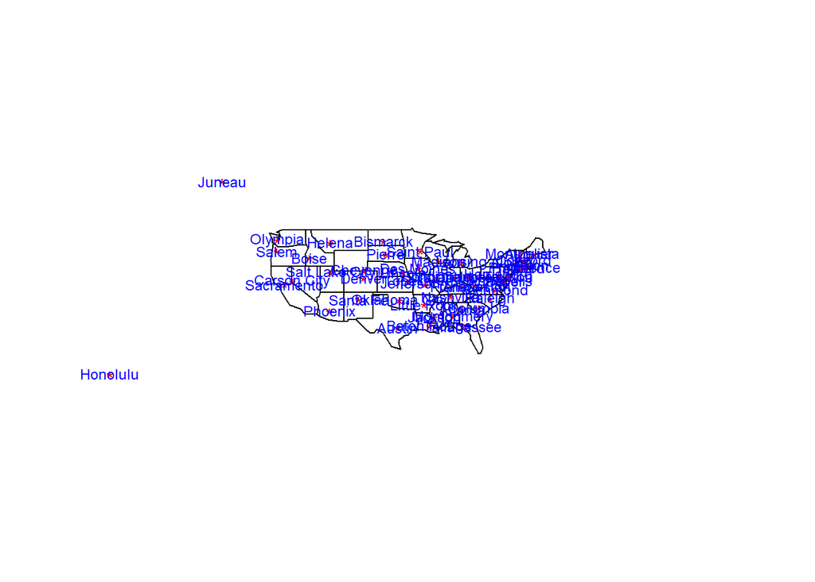

```r
# https://cran.r-project.org/web/packages/maps/maps.pdf
# https://github.com/adeckmyn/maps
map('state', plot = TRUE, fill = FALSE,
    col = palette(), myborder = 0.5
    );
points(x = latlong$longitude, y = latlong$latitude,
                  col = "red", pch = "*", cex = 1);
text(x = latlong$longitude, y = latlong$latitude,
                  labels = latlong$capital,
                  col = "blue", cex=0.75);
```

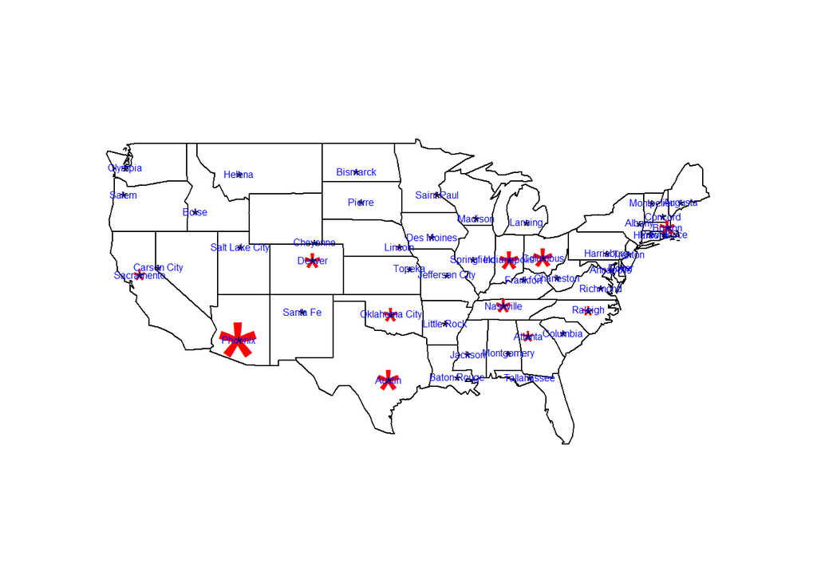

```r
## no alaska / hawaii
map('state', plot = TRUE, fill = FALSE,
    col = palette(), myborder = 0.1
    );
points(x = latlong$longitude, y = latlong$latitude,
                  col = "red", pch = "*", cex = 6 * pop.smax);
points(x = latlong$longitude, y = latlong$latitude,
                  col = "black", pch = "*", cex = 1);
text(x = latlong$longitude, y = latlong$latitude,
                  labels = latlong$capital,
                  col = "blue", cex=0.5);
```

### 5.1.2 usmap

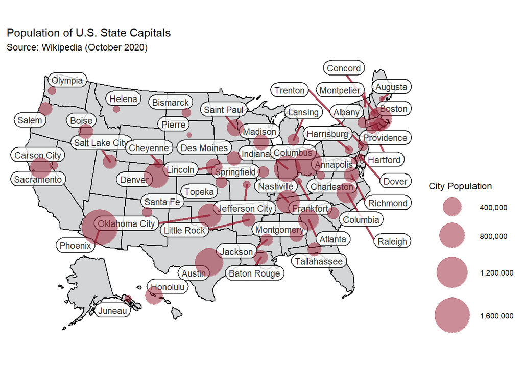

```r
library(humanVerseWSU);
latlong = removeAllColumnsBut(capitals,c("State","Capital","latitude","longitude","Population..2019.est..") );

colnames(latlong) = c("state","capital","latitude","longitude","population");

# first two elements have to be this
latlong = moveColumnsInDataFrame(latlong, c("longitude","latitude"), "before", "state");
# for transform to work


library(usmap);
latlong.transform = usmap_transform(latlong);



# https://cran.r-project.org/web/packages/usmap/usmap.pdf
# this is the ggplot2 universe for those that want to play there ...


## https://cran.r-project.org/web/packages/usmap/vignettes/advanced-mapping.html
library(usmap);
library(ggplot2);

# # CRIMSON ... #981E32
# GRAY ... #53565A

plot_usmap(fill = "#53565A", alpha = 0.25) +
  ggrepel::geom_label_repel(data = latlong.transform,
             aes(x = longitude.1, y = latitude.1, label = capital),
             size = 3, alpha = 0.8,
             label.r = unit(0.5, "lines"), label.size = 0.5,
             segment.color = "#981E32", segment.size = 1,
             seed = 1002) +
  geom_point(data = latlong.transform,
             aes(x = longitude.1, y = latitude.1, size = population),
             color = "#981E32", alpha = 0.5) +
  scale_size_continuous(range = c(1, 16),
                        label = scales::comma) +
  labs(title = "Population of U.S. State Capitals",
       subtitle = "Source: Wikipedia (October 2020)",
       size = "City Population") +
  theme(legend.position = "right")
```

## 5.2 Which is better?

Are we in “geek mode” (building a graphic that is meaningful for ourselves) or in “presentation mode” (buidling a graphic for others). My two cents will always be, build it out quickly, possibly a bit “rough” around the edgest, but focus on the quality of the data measures.

Neither `plot` or ``ggplot2` would be good final graphs as they are subfeatures of a stats programming language `R`. The best solution to a nice dynamice graphic for (presentation mode) would be a nice graphing library designed for HTML5 such as highcharts. https://www.highcharts.com/

#### 5.2.0.1 Highcharts Example

So I took this example https://www.highcharts.com/demo/maps/eu-capitals-temp.

#### 5.2.0.2 Highcharts Example - my hack

And I hacked it, to create this result: http://md5.mshaffer.com/WSU_STATS419/_EXAMPLES_/fiddle_usmap/

It uses our data, output with the command `rjson::toJSON(latlong);`

# 6 The concept of “one” graphic

For a given location, create a summary of the climate data. The base information for a given location is seen here: https://en.wikipedia.org/wiki/Whitefish%2C_Montana#Climate

The x-axis likely should have 12 “tickmarks” with labels “Jan, Feb, Mar, … Dec”

The y-axis likely should be split. The “lower split” could have the temperature data (use the units that are most consistent with your tradition; either F or C). Shading between Record, Average High/Lows would be cool (shade between lines if possible … yellows, oranges, reds generally mean hot; blues generally mean cool), with maybe the Daily mean being a plain black color.

The “upper split” should have precipitation and snowfall. They may be on different units (so a split of the “upper split”). Snowflakes or raindrops would be cool, see https://stackoverflow.com/questions/28042220/how-to-make-custom-plot-symbols-from-vector-graphics-in-r

I have purchased a few more “vector-stock” elements related to temperature that you may find useful:

`DROPBOX:: __student_access__\__vector_stock__\temperature`

## 6.1 Comments - R mockup

You are welcome to use ``ggplot2` or `plot` or other plotting options you find. The goal is initially to build a meaningful “geek-mode graphic” that has the content where you want it. Since the data is rather static, it is possible that we don’t need a dynamic/interactive mode.

- https://davetang.org/muse/2020/01/08/plotting-weather-data-using-r/ More data is not always better. Less is More. Keep it Simple Silly (KISS).
- https://stackoverflow.com/questions/16066583/plotting-monthly-and-yearwise-weather-data-in-r Using gray/white to separate content can be useful at times; and other times can be distracting.
- https://towardsdatascience.com/the-art-of-data-visualization-weather-data-visualization-using-matplotlib-and-ggplot2-4d4b48b5b7c4 Do you think these results are good?
- https://www.benjaminbell.co.uk/2018/01/getting-climate-data.html Provides a link to get more data using `cru`.
- https://towardsdatascience.com/a-guide-to-data-visualisation-in-r-for-beginners-ef6d41a34174 Nice tutorial/walkthrough for basics of `plot` and `ggplot2`
- You will showcase your “result” on the **midterm** exam next week. Sub-element selection will create a mood for your graphic https://www.google.com/search?q=raindrops&tbm=isch&tbs=itp:clipart. Happy, sad, playful, professional, and so on.

## 6.2 TODO

The “one graph” idea is to visually tell a story with just one graph.

Some ideas:

- I would suggest using `lty` line type
  - 1=solid (default)
  - 2=dashed
  - 3=dotted
  - 4=dotdash
  - 5=longdash
  - 6=twodash
- I would suggest using `lwd` line thickness
  - 1 is default
  - 0.25 is thinner
  - 3 is thicker
- I would suggest using `col` for color https://www.datanovia.com/en/blog/top-r-color-palettes-to-know-for-great-data-visualization/#scientific-journal-color-palettes or https://www.r-bloggers.com/2016/07/creating-color-palettes-in-r/
- I would suggest using `pch` for point type http://www.endmemo.com/r/pchsymbols.php
- I would suggest using `type` for “b”

http://md5.mshaffer.com/WSU_STATS419/_data_/my.times

Above are `plot` suggestions, and you are welcome to use ``ggplot2` if that is your thing.

## 6.3 Your graph goes here

Create a “one graph” for “Whitefish, Montana” Climate Data using R … https://en.wikipedia.org/wiki/Whitefish%2C_Montana#Climate.

You would source it as being from Wikipedia (Accessed October X, 2020).